# A-SA24204129-Homework

2024-12-06

# 作业2024-09-09

## *Example 1：主成分分析*

$\hspace{1.5em}$在许多实际应用中，收集到的海量数据往往价值密度较低，包含大量噪声和冗余，高维的数据暗藏着低维的结构。基于此，降维技术应运而生，其中最常用的就是**主成分分析(principal component analysis, PCA)**。

$\hspace{1.5em}$主成分是将自变量进行新的线性组合，生成新的信息表达方式，在尽量不损失原始数据信息的情形下，将数据信息进行有效地转换与压缩。同时，主成分互不相关的性质对解释以及之后的统计分析都有帮助。

### **理论部分**

$\hspace{1.5em}$假设研究数据包括样本和变量的数目分别为$n$和$p$。$p$个变量按顺序表示为$X_1,X_2,…,X_p$，由这$p$个变量构成的随机向量可表示为$\textbf{X}=(X_1,X_2,…,X_p)'$.$\mu$表示$\textbf{X}$的均值，$\Sigma$表示$\textbf{X}$的协方差矩阵。Y表示提取到的主成分，则主成分由原始变量线性表示，如下式：
$$\begin{align}\left\{\begin{aligned}
\begin{matrix}
Y_1=c_{11}X_1+C_{21}X_2+…+c_{p1}X_p=\textbf{c}_1^TX\\
Y_2=c_{12}X_1+C_{22}X_2+…+c_{p2}X_p=\textbf{c}_2^TX\\
……\\
Y_p=c_{11}X_1+C_{21}X_2+…+c_{p1}X_p=\textbf{c}_1^TX\\
\end{matrix}
\end{aligned}\right.\end{align}$$

$\hspace{1.5em}$在$Y_i=c_i'\textbf{X}$的方差尽可能大且各$Y_i$之间相互独立的前提下，求解出的主成分会损失原始变量较少的信息。$Y_i$的方差可表示为$Var(Y_i)=Var(c_i'\textbf{X})=c_i'\Sigma c_i$，对于任意常数$k$，有$Var(k c_i'\textbf{X})=k^2 c_i'\Sigma c_i$。需要限制$c_i$的值，使$Var(Y_i)$不能任意增大，所以在进行线性变换时要满足一定的约束条件：

$\hspace{1.5em}$(1)$c_i'c_i=1,(i=1,2,…,p)$;

$\hspace{1.5em}$(2)主成分$Y_i$与$Y_j$之间互不相关($i\neq j, i,j=1,2,…,p$);

$\hspace{1.5em}$(3)在$\textbf{X}$的所有满足约束条件(1)的线性组合中，方差最大的是$Y_1$；在与$Y_1$不相关的所有$\textbf{X}$的线性组合中，方差最大的是$Y_2$；以此类推，在与$Y_1,Y_2,…,Y_p$都不相关的所有$\textbf{X}$的线性组合中，方差最大的是$Y_p$。

### **R软件实现**

$\hspace{1.5em}$下面是主成分分析经典的一个数值模拟方法(Zou等，2006),我们将基于这个模拟数据进行操作。${V_1},{V_2},{V_3}$分别是三个潜在主成分，分别满足 ${V_1}\sim N(0,290)$,${V_2}\sim N(0,300)$,${V_3}=-0.3V_1+0.925V_2+e,e\sim N(0,1)$,且$V_1,V_2$与$e$相互独立。设有10个变量，其构造方式如下：
$$\begin{align}
X_i&=V_1+e_i^1,e_i^1\sim N(0,1),i=1,2,3,4;
\\
X_i&=V_2+e_i^2,e_i^2\sim N(0,1),i=5,6,7,8;
\\
X_i&=V_3+e_i^3,e_i^3\sim N(0,1),i=9,10.
\end{align}$$
其中 {$e_i^j,i=1,2,…,10,j=1,2,3$} 相互独立。R语言运行结果如下：

```
## [1] 1000000      10
```

|  | PC1 | PC2 | PC3 |
| --- | --- | --- | --- |
| X1 | -0.124 | 0.476 | -0.088 |
| X2 | -0.125 | 0.476 | -0.088 |
| X3 | -0.125 | 0.476 | -0.086 |
| X4 | -0.125 | 0.476 | -0.089 |
| X5 | 0.389 | 0.152 | 0.275 |
| X6 | 0.389 | 0.152 | 0.277 |
| X7 | 0.389 | 0.152 | 0.273 |
| X8 | 0.389 | 0.152 | 0.275 |
| X9 | 0.408 | 0.000 | -0.577 |
| X10 | 0.408 | 0.000 | -0.578 |
| 方差贡献率(%) | 59.793 | 39.887 | 0.082 |
| 累积贡献率(%) | 59.793 | 99.681 | 99.762 |

## *Example 2：寻找组间差异——t检验*

$\hspace{1.5em}$在研究中，我们最常关注的问题莫过于处理组与对照组是否存在了显著不同。就两组间比较而言，t检验是常见的分析方法之一。

$\hspace{1.5em}$鸢尾花(Iris)数据集是机器学习领域中最经典的数据集之一。它由三种不同品种的鸢尾花的测量数据组成：山鸢尾(setosa)、变色鸢尾(versicolor)和维吉尼亚鸢尾(virginica)。该数据集包含150个样本，每行数据包含每个样本的四个特征：花萼长度(sepal length)、花萼宽度(sepal width)、花瓣长度(petal length)、花瓣宽度(petal width)。

$\hspace{1.5em}$接下来,使用 iris 数据集中的 Sepal.Length 进行 t 检验，比较不同种类的 Sepal.Length 是否有显著差异。

### **正态性假设检验**

$\hspace{1.5em}$t检验的一个重要前提就是数据必须符合*正态分布*。因此在执行t检验之前必须验证数据分布的正态性。若数据不符合正态分布，则t检验将无法适用于该数据。首先绘制QQ图查看数值分布，如果点大致沿着对角线分布，说明数据可能近似正态分布；偏离对角线可能表明数据不完全符合正态分布。结果如下图所示。

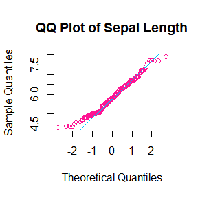

$\hspace{1.5em}$横坐标是标准的正态分布值，纵坐标是我们数据的值。可以看到大部分的点都离直线很近，大致沿着对角线分布，因此可以认为该数据符合正态性假设。

### **t检验**

$\hspace{1.5em}$接下来对数据进行独立样本的 t 检验，即分别两两比较不同种类的 Sepal.Length。R软件操作得到三组结果如下：

```
##
##  Two Sample t-test
##
## data:  setosa and versicolor
## t = -10.521, df = 98, p-value < 2.2e-16
## alternative hypothesis: true difference in means is not equal to 0
## 95 percent confidence interval:
##  -1.1054165 -0.7545835
## sample estimates:
## mean of x mean of y
##     5.006     5.936
```

```
##
##  Two Sample t-test
##
## data:  setosa and virginica
## t = -15.386, df = 98, p-value < 2.2e-16
## alternative hypothesis: true difference in means is not equal to 0
## 95 percent confidence interval:
##  -1.786042 -1.377958
## sample estimates:
## mean of x mean of y
##     5.006     6.588
```

```
##
##  Two Sample t-test
##
## data:  versicolor and virginica
## t = -5.6292, df = 98, p-value = 1.725e-07
## alternative hypothesis: true difference in means is not equal to 0
## 95 percent confidence interval:
##  -0.8818516 -0.4221484
## sample estimates:
## mean of x mean of y
##     5.936     6.588
```

$\hspace{1.5em}$可以看到，结果的p值均小于显著性水平0.01，这表明两组间的 Sepal.Length 存在显著差异。

### **可视化——箱线图**

$\hspace{1.5em}$箱线图能帮助我们更直观地了解数据的分布情况、中心趋势和离群情况。观察三组的箱体，发现在中位数、四分位数和异常值有着较为明显的差异。

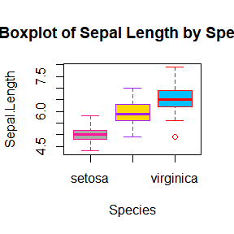

## *Example 3：一元线性回归分析*

$\hspace{1.5em}$一元线性回归分析是一种最常用、最简单的估计。

$\hspace{1.5em}$R中自带的women数据集储存了15个年龄在30~39岁间的女性的身高和体重信息，我们将建立一元线性回归模型，试图通过身高预测体重。

### **模型构建与解读**

$\hspace{1.5em}$。散点图可以判断两个变量之间有无相关关系，并对变量间的关系形态做出大致的描述:

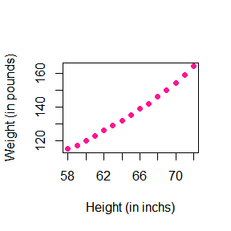

$\hspace{1.5em}$可以看到散点分布呈现线性规律，说明适合构建线性回归方程。

$\hspace{1.5em}$接着构建模型,用summary函数查看拟合模型结果如下:

```
##
## Call:
## lm(formula = women$weight ~ women$height)
##
## Residuals:
##     Min      1Q  Median      3Q     Max
## -1.7333 -1.1333 -0.3833  0.7417  3.1167
##
## Coefficients:
##               Estimate Std. Error t value Pr(>|t|)
## (Intercept)  -87.51667    5.93694  -14.74 1.71e-09 ***
## women$height   3.45000    0.09114   37.85 1.09e-14 ***
## ---
## Signif. codes:  0 '***' 0.001 '**' 0.01 '*' 0.05 '.' 0.1 ' ' 1
##
## Residual standard error: 1.525 on 13 degrees of freedom
## Multiple R-squared:  0.991,  Adjusted R-squared:  0.9903
## F-statistic:  1433 on 1 and 13 DF,  p-value: 1.091e-14
```

$$weight=-87.5166667+3.45*height$$

进一步用图像对模型进行回归诊断：

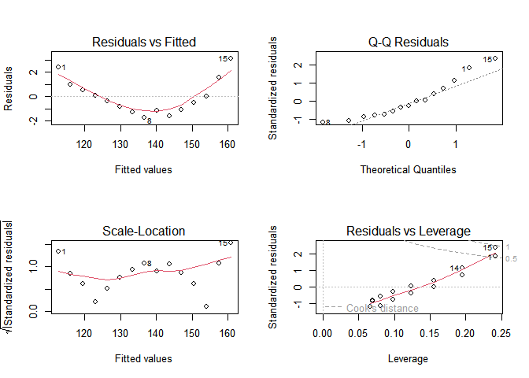

1）左上图为**残差与拟合图**，理论上散点应该散乱的分布在横线两侧，但是此图明显有一个曲线关系，说明我们的模型需要加入一个二次项。

2）右上图是一个**正态Q-Q图**，用于检验因变量的正态分布性，若服从，则散点应分布在一条直线上。可以看出该图是符合这一条件的，表明满足正态性假设。

3）左下图为**齐方差检验**，若满足其方差，则散点在水平线周围随机分布，此图满足齐方差检验。

4）右下图是**独立性检验**，即一个样本是否会影响另一个样本，我们的样本数据并不存在这样的问题。

### **模型修正**

$\hspace{1.5em}$根据以上分析，我们对模型引入一个二次项，得到结果如下：

```
##
## Call:
## lm(formula = women$weight ~ women$height + squ_h)
##
## Residuals:
##      Min       1Q   Median       3Q      Max
## -0.50941 -0.29611 -0.00941  0.28615  0.59706
##
## Coefficients:
##               Estimate Std. Error t value Pr(>|t|)
## (Intercept)  261.87818   25.19677  10.393 2.36e-07 ***
## women$height  -7.34832    0.77769  -9.449 6.58e-07 ***
## squ_h          0.08306    0.00598  13.891 9.32e-09 ***
## ---
## Signif. codes:  0 '***' 0.001 '**' 0.01 '*' 0.05 '.' 0.1 ' ' 1
##
## Residual standard error: 0.3841 on 12 degrees of freedom
## Multiple R-squared:  0.9995, Adjusted R-squared:  0.9994
## F-statistic: 1.139e+04 on 2 and 12 DF,  p-value: < 2.2e-16
```

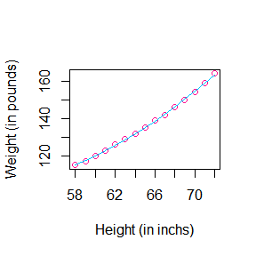

$\hspace{1.5em}$得到的$adj.R^2$提高到0.9994,对比来看，模型拟合效果得到提升。

# 作业2024-09-14

## *习题3.4*

### 答：

$\hspace{1.5em}$**Rayleigh 分布**（瑞利分布）是概率论中的一种概率分布，其概率密度函数如下：
$$f(x)=\frac{x}{\sigma^2}e^\frac{-x^2}{2\sigma^2}$$
其中,$\sigma$是分布的尺度参数。其分布函数为：
$$F(x)=1-e^\frac{-x^2}{2}$$
$\hspace{1.5em}$下面将选取$\sigma$分别为**0.5、1、2、4**，从瑞利分布中生成随机样本。并利用**直方图**检验生成的样本的模式是否接近理论模式。由于瑞利分布为连续型分布，这里我们选用**逆变换法**。即首先生成一个0到1上的均匀分布U,再利用逆变换$X=F_X^{-1}(U)$生成随机数X。最终得到结果如下图所示。

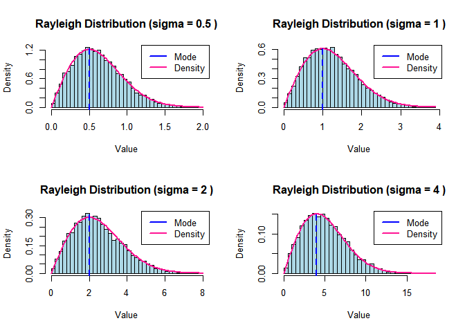

```r
# 设置随机种子 可复现
set.seed(1234)

# 定义生成瑞利分布样本的函数
rayleigh_samples = function(sigma, n) {
  U = runif(n) #生成[0,1]
  samples = sigma * sqrt(-2 * log(U)) #逆变换
  return(samples)
}

# 选取一系列Rayleigh分布的参数sigma
sigmas=c(0.5,1,2,4)
n=8000  # 样本数量

# 循环生成样本并绘制直方图
par(mfrow = c(2, 2))  # 设置图形布局2×2
for (sigma in sigmas)
  {
  samples = rayleigh_samples(sigma, n)
  # 绘制直方图
  hist(samples, breaks = 30, main = paste("Rayleigh Distribution (sigma =", sigma, ")"),
       xlab = "Value", col = "lightblue", border = "black", prob = TRUE)
  # 添加理论密度函数曲线
  curve((x / sigma^2) * exp(-x^2 / (2 * sigma^2)), add = TRUE, col = "deeppink", lwd = 2)

  # 添加众数线
  abline(v = sigma, col = "blue", lwd = 2, lty = 2)  # 理论众数
  legend("topright", legend = c('Mode', "Density"), col = c("blue", "deeppink"), lwd = 2)
}
```

```r
par(mfrow = c(1, 1)) # 还原图形布局
```

$\hspace{1.5em}$从上图我们可以看到，模拟的分布直方图和概率密度函数形状接近，这表明我们的模拟是可以接受的。同时通过几张图的对比可以看出，尺度参数 σ 的值越大，分布就越宽。

## *习题3.11*

### 答：

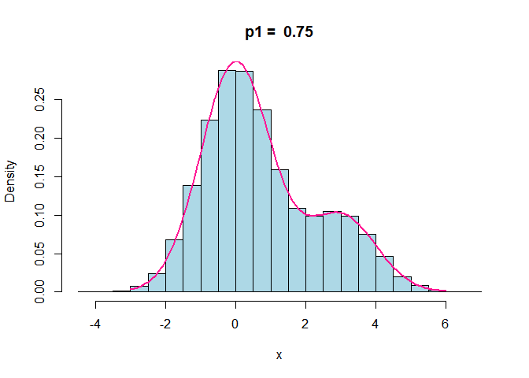

```r
set.seed(1234)
# 创建一个函数模拟并生成直方图
mix_hist=function(n,p1, co='lightblue')
  #参数n为生成随机样本数,p1为N(0,1)的混合概率,co为绘制颜色
{
  p=rbinom(n,1,prob = p1)
  #生成两个正态分布随机数 N(0,1)和N(3,1)
  x1=rnorm(n)
  x2=rnorm(n,3,1)
  x=p*x1+(1-p)*x2 #混合
  #绘制直方图
  title=paste('p1 = ',p1)
  hist(x,probability = T,main = title,col = co)
  #理论密度函数
  densityplot=function(x)
    {
      p1*dnorm(x)+(1-p1)*dnorm(x,3,1)
  }
  y=seq(-3,6,0.1)
  lines(y,densityplot(y),col='deeppink',lwd=2)
}

mix_hist(50000,0.75)#p1=0.75的情况
```

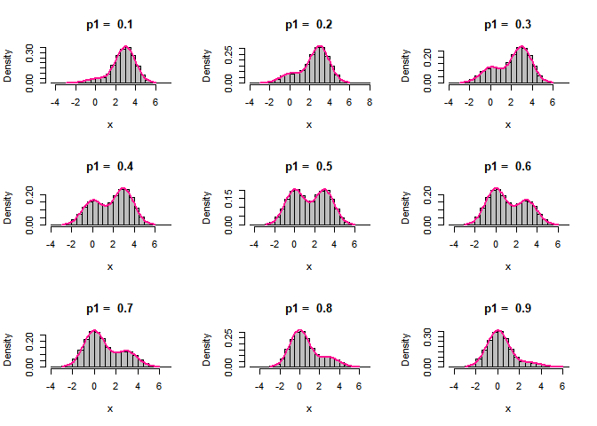

```r
par(mfrow = c(3, 3))  # 设置图形布局3×3
for (p1 in seq(0.1,0.9,0.1)) #p1取值为0.1,0.2,……,0.9
  {
  mix_hist(50000,p1,'gray')
  }
```

```r
par(mfrow = c(1, 1)) # 还原图形布局
```

$\hspace{1.5em}$由结果图看出，对于$p1$的取值，当$p1$值接近0.5时，分布更倾向于双峰。而更高的值，如 $p1>$ 0.75，导致以第一个分量为中心的单峰分布；更低的值，如 $p1<$ 0.3，导致以第二个分量为中心的单峰分布。

## *习题3.20*

### 答：

```r
set.seed(1234)
# 函数一：复合泊松-伽马过程模拟函数
com_poisson_gamma = function(lambda_rate, alpha, beta, T, num)
  {
  X_T = numeric(num)  # 初始化结果向量

  for (i in 1:num) {
    # 生成泊松过程中的事件数量
    N_T = rpois(1, lambda_rate * T)
    # 生成伽马分布的随机变量并求和
    if (N_T > 0)
      {
      Y = rgamma(N_T, shape = alpha, rate = beta)
      X_T[i] = sum(Y)}
    else {
      X_T[i] = 0}
  }
  return(X_T)
}

# 函数2：估计平均值和方差
mean_var = function(X_T, lambda_rate, alpha, beta, T) {
  emp_mean = mean(X_T)
  emp_var = var(X_T)
  theo_mean = lambda_rate * T * (alpha / beta)
  theo_var = lambda_rate * T * ((alpha * (alpha + 1)) / beta^2 - (alpha / beta)^2)
  return(list(emp_mean = emp_mean,
              emp_var = emp_var,
              theo_mean = theo_mean,
              theo_var = theo_var))
}

# 参数设置
lambda_rate = 2.0  # 泊松率参数
alpha = 2.0        # 伽马分布形状参数
beta = 1.0         # 伽马分布率参数
T = 10             # 时间
num = 50000        # 模拟次数

# 运行模拟
X_T = com_poisson_gamma(lambda_rate, alpha, beta, T, num)

# 估计平均值和方差
results = mean_var(X_T, lambda_rate, alpha, beta, T)
# 计算实验的平均值和标准差
emp_mean = results$emp_mean
emp_sd = sqrt(results$emp_var)


# 创建一个数据框以便输出为表格
result_table = data.frame(
  Statistic = c("实验平均值", "理论平均值", "实验方差", "理论方差"),
  Value = c(results$emp_mean, results$theo_mean, results$emp_var, results$theo_var)
)
knitr::kable(result_table, caption = "复合泊松-伽马过程的模拟统计结果")
```

复合泊松-伽马过程的模拟统计结果

| Statistic | Value |
| --- | --- |
| 实验平均值 | 40.02137 |
| 理论平均值 | 40.00000 |
| 实验方差 | 119.22625 |
| 理论方差 | 40.00000 |

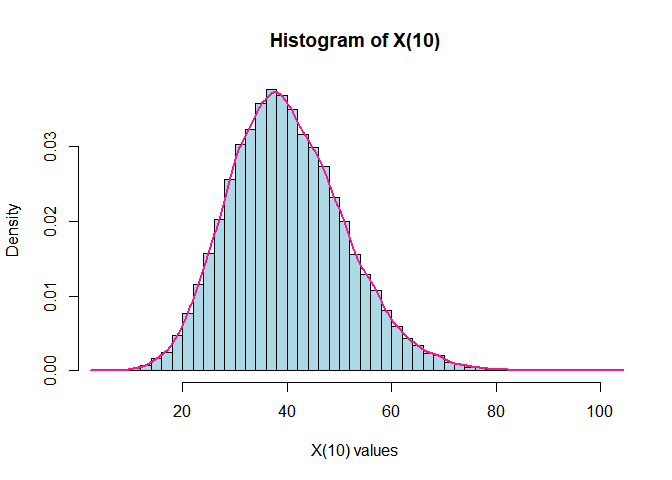

```r
# 绘制直方图
hist(X_T, breaks = 50, main = "Histogram of X(10)",
     xlab = "X(10) values", col = "lightblue", probability = TRUE)
# 绘制核密度估计曲线
density_curve = density(X_T, adjust = 1)
lines(density_curve, col = "deeppink", lwd = 2)

text(x = max(density_curve$x) * 0.9, y = max(density_curve$y) * 1.1,
     labels = "Kernel Density Estimate", pos = 4, col = "red")
```

# 作业2024-09-23

## *习题5.4*

$\hspace{1.5em}$编写一个函数来计算Beta(3,3)的蒙特卡罗估计数，并使用该函数来估计x =0.1,0.2，…，0.9的F(x)。将估计值与R中的pbeta函数返回的值进行比较。

### 答：

```r
# 加载必要的包
library(ggplot2)
# 设置参数
n = 10000  # 蒙特卡罗样本数量
a = 3      # Beta 分布的第一个形状参数
b = 3      # Beta 分布的第二个形状参数

# Monte Carlo 估计 CDF 的函数
mc.cdf.beta = function(p, n, shape1, shape2)
  {
  if (p <= 0 || p >= 1) return(0)  # 确保 p 在 (0, 1) 范围内
  samples = rbeta(n, shape1, shape2)  # 生成 n 个 Beta 分布的样本
  return(mean(samples <= p))  # 计算小于等于 p 的比例
}

# 要估计的 x 值
x_values = seq(0.1, 0.9, by = 0.1)

# 计算 Monte Carlo 估计和精确 CDF
mc_estimates = sapply(x_values, function(x) mc.cdf.beta(x, n, a, b))
exact_values = sapply(x_values, function(x) pbeta(x, a, b))

# 输出结果
result = data.frame(
  x = x_values,
  Monte_Carlo_Estimate = mc_estimates,
  Exact_Value = exact_values
)
knitr::kable(result, caption = "Monte Carlo 估计和精确 CDF比较表",digits = 3)
```

Monte Carlo 估计和精确 CDF比较表

| x | Monte_Carlo_Estimate | Exact_Value |
| --- | --- | --- |
| 0.1 | 0.009 | 0.009 |
| 0.2 | 0.060 | 0.058 |
| 0.3 | 0.161 | 0.163 |
| 0.4 | 0.312 | 0.317 |
| 0.5 | 0.500 | 0.500 |
| 0.6 | 0.688 | 0.683 |
| 0.7 | 0.837 | 0.837 |
| 0.8 | 0.942 | 0.942 |
| 0.9 | 0.990 | 0.991 |

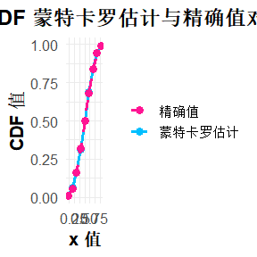

```r
# 绘制对比图
ggplot(result, aes(x = x)) +
  geom_line(aes(y = Monte_Carlo_Estimate, color = "蒙特卡罗估计"), linewidth = 1.2) +
  geom_point(aes(y = Monte_Carlo_Estimate, color = "蒙特卡罗估计"), size = 3) +
  geom_line(aes(y = Exact_Value, color = "精确值"), linewidth = 1.2, linetype = "dashed") +
  geom_point(aes(y = Exact_Value, color = "精确值"), size = 3) +
  labs(title = "Beta(3, 3) CDF 蒙特卡罗估计与精确值对比",
       x = "x 值",
       y = "CDF 值") +
  scale_color_manual(values = c("蒙特卡罗估计" = "deepskyblue", "精确值" = "deeppink")) +
  theme_minimal(base_size = 15) +  # 增加基础字体大小
  theme(
    legend.title = element_blank(),
    plot.title = element_text(hjust = 0.5, size = 18, face = "bold"),  # 标题居中并加粗
    axis.title.x = element_text(face = "bold"),  # X轴标题加粗
    axis.title.y = element_text(face = "bold")   # Y轴标题加粗
  )
```

$\hspace{1.5em}$我们通过**数值**和**图像可视化**形式分别进行对比，得到具体结果如上表和上图所示。可以看到，模拟结果很好，与pbeta函数返回的值相差不大。

## *习题5.9*

### 答:

#### Rayleigh分布

$\hspace{1.5em}$Rayleigh分布的概率密度函数为：

$$f(x)=\frac{x}{\sigma^2}e^\frac{-x^2}{2\sigma^2},x\geq0,\sigma>0$$
使用逆变换法生成随机样本。

#### 对立变量

$\hspace{1.5em}$对立变量技术涉及生成两个负相关的变量$X_1$和$X_2$。设U是均匀分布在[0,1]的随机变量，使用U生成$X_1$，使用1-U生成$X_2$

[figure not shown]

```r
# 函数：生成Rayleigh分布样本
rayleigh_sample <- function(sigma, n_samples) {
  U <- runif(n_samples)  # 生成均匀分布随机数
  X1 <- sigma * sqrt(-2 * log(U))       # 使用U生成X1
  X2 <- sigma * sqrt(-2 * log(1 - U))   # 使用(1-U)生成X2
  return(list(X1 = X1, X2 = X2))
}

# 函数：计算方差减少并绘制图形
variance_reduction_and_plot <- function(sigma, n_samples)
  {
  samples <- rayleigh_sample(sigma, n_samples)
  X1 <- samples$X1
  X2 <- samples$X2

  # 计算对立变量的平均
  X_plus_antithetic <- (X1 + X2) / 2

  # 独立变量生成
  independent_X1 <- sigma * sqrt(-2 * log(runif(n_samples)))
  independent_X2 <- sigma * sqrt(-2 * log(runif(n_samples)))
  X_plus_independent <- (independent_X1 + independent_X2) / 2

  # 计算方差
  var_antithetic <- var(X_plus_antithetic)
  var_independent <- var(X_plus_independent)

  # 计算方差减少百分比
  percent_reduction <- (var_independent - var_antithetic) / var_independent * 100

  # 绘制直方图
  par(mfrow = c(1, 2))  # 设置图形区域为1行2列

  hist(X_plus_independent, breaks = 30, col = 'deepskyblue',
       main = '独立变量生成的Rayleigh样本',
       xlab = '样本值',
       ylab = '频率',
       xlim = c(0, max(X_plus_independent, X_plus_antithetic)),
       probability = TRUE)

  hist(X_plus_antithetic, breaks = 30, col = 'deeppink',
       main = '对立变量生成的Rayleigh样本',
       xlab = '样本值',
       ylab = '频率',
       xlim = c(0, max(X_plus_independent, X_plus_antithetic)),
       probability = TRUE)

  legend("topright", legend = c("独立变量", "对立变量"),
         fill = c("deepskyblue", "deeppink"))

  return(percent_reduction)
}

# 示例使用
sigma <- 1.0  # 参数
n_samples <- 10000  # 样本数量
reduction <- variance_reduction_and_plot(sigma, n_samples)
title(main = paste("\nσ =", sigma), outer = TRUE)
```

```r
cat(sprintf("方差减少百分比: %.2f%%\n", reduction))
```

```
## 方差减少百分比: 94.71%
```

## *习题5.13*

### 答：

$\hspace{1.5em}$对于重要性分布$f_1$,由于Gamma分布在 (1,$\infty$)上有较好的支持，因此选择参数为$\alpha$=3,$\beta$=1的Gamma分布，即：
$$f_1(x) = \frac{\beta^\alpha}{\Gamma(\alpha)} x^{\alpha-1} e^{-\beta x}
= \frac{1^3}{2} x^{3-1} e^{-x} = \frac{1}{2} x^2 e^{-x}$$

$\hspace{1.5em}$对重要性分布 $f_2$，我们可以选择正态分布，例如 $N(\mu=2, \sigma^2=1)$，在 (1,$\infty$) 区间上也是合适的。正态分布的概率密度函数为：
$$f_2(x) = \frac{1}{\sqrt{2\pi}} e^{-\frac{(x-2)^2}{2}}$$

```r
# 加载必要的库
library(ggplot2)
# 设置随机种子以确保结果可重复
set.seed(1234)
# 定义目标分布 g(x)
g <- function(x) {
  (x^2 / sqrt(2 * pi)) * exp(-x^2 / 2)
}
# 定义重要性分布 f1 (Gamma 分布) 和 f2 (正态分布)
f1 <- function(x) {
  (x^2 * exp(-x)) / 2 # Gamma(3, 1) 的 PDF
}
f2 <- function(x) {
  dnorm(x, mean = 2, sd = 1) # N(2, 1) 的 PDF
}
# 重要性采样函数
importance_sampling <- function(g, f, n) {
  samples <- numeric(n)
  if (identical(f, f1)) {
    samples <- rgamma(n, shape = 3, rate = 1)
  } else if (identical(f, f2)) {
    samples <- rnorm(n, mean = 2, sd = 1)
  }
  # 计算权重
  weights <- g(samples) / sapply(samples, f)
  # 计算估计值和方差
  estimate <- mean(weights)
  variance <- var(weights) / n
  return(list(estimate = estimate, variance = variance, samples = samples))
}

# 执行重要性采样
n_samples <- 10000
result_f1 <- importance_sampling(g, f1, n_samples)
result_f2 <- importance_sampling(g, f2, n_samples)

results_df <- data.frame(
  Distribution = c("Gamma", "Normal"),
  Estimate = c(result_f1$estimate, result_f2$estimate),
  Variance = c(result_f1$variance, result_f2$variance)
)

# 输出结果为表格
knitr::kable(results_df, caption = "重要性采样结果")
```

重要性采样结果

| Distribution | Estimate | Variance |
| --- | --- | --- |
| Gamma | 0.496716 | 0.0000239 |
| Normal | 1.116925 | 0.0907373 |

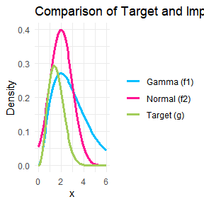

```r
# 可视化目标分布和重要性分布
x_vals <- seq(0, 6, length.out = 100)
target_density <- g(x_vals)
gamma_density <- f1(x_vals)
normal_density <- f2(x_vals)

# 创建数据框用于 ggplot
data_plot <- data.frame(
  x = rep(x_vals, 3),
  density = c(target_density, gamma_density, normal_density),
  distribution = rep(c("Target (g)", "Gamma (f1)", "Normal (f2)"), each = length(x_vals))
)

# 绘制图像
ggplot(data_plot, aes(x = x, y = density, color = distribution)) +
  geom_line(linewidth = 1.2) +
  labs(title = "Comparison of Target and Importance Distributions",
       x = "x", y = "Density") +
  theme_minimal() +
  scale_color_manual(values = c("deepskyblue", "deeppink", "darkolivegreen3")) +
  theme(legend.title = element_blank())
```

# 作业2024-10-14

## *多重假设检验——Bonferroni与B-H方法的模拟比较*

$\hspace{1.5em}$设在N=1000个假设中,950个是零假设,50个是备择假设。任何**零假设**下的p值都是**均匀分布**的(**runif**)，而任何**备择假设**下的p值都遵循**参数为0.1和1的贝塔分布**(**rbeta**)。

$\hspace{1.5em}$分别获取**Bonferroni调整**和**B-H调整**后的p值。进行m=10000次模拟重复，计算两种调整方法中每种方法在名义水平$\alpha$=0.1下的FWER、FDR和TPR。将结果输出到3×2表格中，进一步进行分析。

### 代码实现：

```r
rm(list=ls())
#设置种子
set.seed(12345)
# 参数设定
N=1000  # 总假设数
num0=950  # 零假设数
num1=50  # 备择假设数
m=10000  # 模拟次数
alpha=0.1  # 显著性水平

# 初始化存储结果的表格
results=matrix(0, nrow=m, ncol=6)
# 模拟
for (i in 1:m) {
  ## 生成p值
  # 零假设使用均匀分布，备择假设使用贝塔分布
  p_values=c(runif(num0), rbeta(num1, 0.1, 1))

  ## 校正
  bo_adjusted=p.adjust(p_values, method = "bonferroni")
  bh_adjusted=p.adjust(p_values, method = "BH")

  #计算拒绝数目
  rejected_bo=sum(bo_adjusted < alpha)
  rejected_bh=sum(bh_adjusted < alpha)

  # 真实拒绝的数目
  true_positive_bo=sum((p_values[(num0 + 1):N] < alpha) & (bo_adjusted < alpha))
  true_positive_bh=sum((p_values[(num0 + 1):N] < alpha) & (bh_adjusted < alpha))

  ## FWER
  fwer_bo=rejected_bo / num0
  fwer_bh=rejected_bh / num0

  ## FDR
  fdr_bo=ifelse(rejected_bo > 0, (num0 - true_positive_bo) / rejected_bo, 0)
  fdr_bh=ifelse(rejected_bh > 0, (num0 - true_positive_bh) / rejected_bh, 0)

  ## TPR
  tpr_bo=true_positive_bo / num1
  tpr_bh=true_positive_bh / num1

  # 存储每次模拟的结果
  results[i, ]=c(fwer_bo, fdr_bo, tpr_bo, fwer_bh, fdr_bh, tpr_bh)
}

# 转换为数据框并计算平均值
results1=as.data.frame(results)
colnames(results1)=c("fwer_bo", "fdr_bo", "tpr_bo",
                     "FWER_BH", "FDR_BH", "TPR_BH")

# 计算每列的平均值
results_mean=colMeans(results1)

# 将平均值整理为3×2表格
table=matrix(results_mean, nrow=3, byrow=FALSE)
rownames(table)=c("FWER", "FDR", "TPR")
colnames(table)=c("Bonferroni校正", "B-H校正")
table=round(table, 3)  # 保留三位小数

# 显示结果
knitr::kable(table)
```

|  | Bonferroni校正 | B-H校正 |
| --- | --- | --- |
| FWER | 0.021 | 0.033 |
| FDR | 48.208 | 30.319 |
| TPR | 0.399 | 0.610 |

### 结果分析：

$\hspace{1.5em}$两种调整方法中每种方法在名义水平$\alpha$=0.1下的FWER、FDR和TPR如上表所示。结果表明，在不同的假设检验中，这两种校正方法的表现有所不同。

#### 1. FWER（家庭错误率）

- **Bonferroni校正**的FWER为 **0.021**，这表示在所有假设检验中，仅有约2.1%的情况下错误拒绝了零假设。
- **B-H校正**的FWER为 **0.033**，略高于Bonferroni校正。这意味着在B-H校正中，错误拒绝的比例相对更高，但仍然保持在可接受的范围内。

**分析**：Bonferroni校正是一种保守的校正方法，能够有效控制FWER，因此其FWER值较低。而B-H校正相对宽松，适合于需要平衡假发现率（FDR）和检出率（TPR）的场景。

#### 2. FDR（假发现率）

**分析**：FDR的比较显示出B-H校正在控制假发现率方面的优势。Bonferroni校正虽然FWER较低，但由于其保守性，容易产生较高的假发现率，不适合于假阳性率需要较低的情形。

#### 3. TPR（真正率）

- **Bonferroni校正**的TPR为 **0.399**，表示约39.9%的真实备择假设得到了正确的拒绝。
- **B-H校正**的TPR为 **0.610**，表明在B-H校正下，接近61%的真实备择假设得到了正确的拒绝。

**分析**：B-H校正的TPR高于Bonferroni校正，意味着它在检出真正的效应方面更为有效。这也与FDR的高低相辅相成，较低的FDR伴随较高的TPR显示出B-H校正在进行多重假设检验时的有效性。

#### 总结

- **Bonferroni校正**适用于对假发现率要求严格的场景，其FWER较低，但可能导致TPR降低和FDR增加。
- **B-H校正**则在保持合理的FWER水平的同时，能够提升TPR并降低FDR，适合大规模假设检验中的应用。

## *习题7.4*

$\hspace{1.5em}$依据boot包中提供的空调数据集aircondit，12个观察结果以空调设备故障的间隔时间为单位(3、5、7、18、43、85、91、98、100、130、230、487)。假设故障间隔时间遵循指数模型Exp($\lambda$)。获得危险率$\lambda$的MLE，并使用bootstrap估计估计的偏差和标准误差。

### 代码实现：

```r
rm(list=ls())
# 加载空调故障时间数据
library(boot)
hours=aircondit$hours
# 设置Bootstrap参数
set.seed(12345)
B=1e4  # 设置Bootstrap次数为10000次

## 计算lambda的 MLE：n/sum(xi)
lambda_hat=length(hours)/sum(hours)
# 初始化存储向量
boot_lambda_hats=numeric(B)
## 进行Bootstrap抽样
for (b in 1:B) {
  boot_hours=sample(hours, replace=TRUE)
  # 计算Bootstrap样本的 MLE
  boot_lambda_hats[b]=length(boot_hours)/sum(boot_hours)
}
## 计算偏差
boot_lambda_hats_mean=mean(boot_lambda_hats)
bias=boot_lambda_hats_mean - lambda_hat
## 计算标准误差
std_error=sd(boot_lambda_hats)

# 结果输出
results=round(c(MLE=lambda_hat,bias=bias, se.boot=std_error,
                se.samp=sd(hours)/sqrt(length(hours))), 4)
knitr::kable(results)
```

|  | x |
| --- | --- |
| MLE | 0.0093 |
| bias | 0.0013 |
| se.boot | 0.0043 |
| se.samp | 39.3268 |

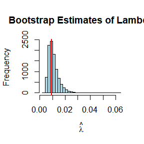

```r
# 绘制Bootstrap均值的直方图
hist(boot_lambda_hats, main="Bootstrap Estimates of Lambda",
     xlab=expression(hat(lambda)),
     breaks=30, col="lightblue", border="black")
abline(v=lambda_hat, col='red', lwd=2)
```

### 结果分析：

- **偏差(Bias)** 值为 0.0013，说明估计值与真实值之间存在微小的偏差，整体来看估计相对准确。
- **自助法标准误(se.boot)** 通过bootstrap计算，用于评估MLE的不确定性，表示在重复抽样过程中MLE的变异程度。相对较小的值(0.0043)表明bootstrap法的MLE具有一定的稳健性。
- **样本标准误 (se.samp)**用于衡量样本统计量的变异性，这个值相对较大，可能是由于样本数量有限，同时样本中有一些极端值（如 230 和 487），这些值会显著增加标准差，从而导致高的标准误差。

## *习题7.5*

$\hspace{1.5em}$使用standard normal, basic, percentile和BCa方法计算故障之间的平均时间$1/\lambda$的95%引导置信区间。比较这些时间间隔，并解释为什么它们可能会有所不同。

```r
library(boot)
# 提取数据
hours=aircondit$hours
# 计算样本均值的倒数
mu=1 / mean(hours)
# 设置随机种子和参数
set.seed(12345)
m=1000
R=999

# 初始化置信区间矩阵
ci.norm=ci.basic=ci.perc=ci.bca=matrix(NA, m, 2)

# 定义fun算平均故障时间
mean_failure_time=function(hours, ind) {
  return(1/mean(hours[ind]))  # lambda的倒数为平均故障时间
}

# 执行自助法抽样
for (i in 1:m) {
  boot_results=boot(data = hours, statistic = mean_failure_time, R = R)
  # 计算各类型的置信区间
  ci=boot.ci(boot_results, type = c("norm", "basic", "perc", "bca"))
  ci.norm[i, ]=ci$norm[2:3]
  ci.basic[i, ]=ci$basic[4:5]
  ci.perc[i, ]=ci$percent[4:5]
  ci.bca[i, ]=ci$bca[4:5]
}

# 计算并打印每种置信区间的平均值
result=list(
  norm = round(colMeans(ci.norm), 4),
  basic = round(colMeans(ci.basic), 4),
  perc = round(colMeans(ci.perc), 4),
  bca = round(colMeans(ci.bca), 4)
)
print(result)
```

```
## $norm
## [1] -0.0005  0.0164
##
## $basic
## [1] -0.0030  0.0133
##
## $perc
## [1] 0.0052 0.0215
##
## $bca
## [1] 0.0046 0.0181
```

```r
# 计算每种置信区间包含mu的比例
cat('norm =', mean(ci.norm[, 1] <= mu & ci.norm[, 2] >= mu), "\n",
    'basic =', mean(ci.basic[, 1] <= mu & ci.basic[, 2] >= mu), "\n",
    'perc =', mean(ci.perc[, 1] <= mu & ci.perc[, 2] >= mu), "\n",
    'BCa =', mean(ci.bca[, 1] <= mu & ci.bca[, 2] >= mu), "\n")
```

```
## norm = 1
##  basic = 1
##  perc = 1
##  BCa = 1
```

# 作业2024-10-21

## *一、习题7.8*

$\hspace{1.5em}$要求使用Jackknife刀切法估计习题7.7中的统计量$\hat{\theta}$的偏误和标准误差，其中$\hat{\theta}$是基于协方差矩阵的主成分分析中第一个特征值所解释的方差比例。

### 代码实现：

```r
rm(list=ls()) #清除内存变量
# 导入数据
library(bootstrap)
scores=scor
# 计算 theta_hat
theta_hat=eigen(cov(scores))$values[1]/sum(eigen(cov(scores))$values)
# Jackknife 估计
n=nrow(scores)
theta_jack=sapply(1:n, function(i) {
  eigen(cov(scores[-i, ]))$values[1]/sum(eigen(cov(scores[-i, ]))$values)
})
# 计算 Jackknife 偏差和标准误差
bias_jack=(n - 1) * (mean(theta_jack) - theta_hat)
se_jack=sqrt((n - 1) * mean((theta_jack - theta_hat)^2))
# 输出结果
results=data.frame(Metric=c("Original", "Bias", "Standard Error"),
  Value=c(round(mean(theta_jack),3), round(bias_jack,3), round(se_jack,3)))
knitr::kable(results, caption="Jackknife方法估计结果")
```

Jackknife方法估计结果

| Metric | Value |
| --- | --- |
| Original | 0.619 |
| Bias | 0.001 |
| Standard Error | 0.050 |

### 结果分析：

$\hspace{1.5em}$Jackknife方法是一种重采样技术，通过系统地从原始样本中移除一个或多个观测值，然后重新计算统计量，以此来估计原始统计量的方差和偏误。根据输出结果：

- **original (0.619)**：是原始样本的估计值，表明在主成分分析中，第一个主成分解释了61.9%的方差，说明样本在该维度上具有较强的解释力。
- **bias (0.001)**：偏误非常小，接近于零，表明使用Jackknife方法后，估计值与原始估计值几乎没有系统性偏差，原始估计较为准确。
- **se (0.050)**：标准误差为0.050，表示虽然有一定的波动，但围绕真实值的变异性相对较小。较小的标准误差意味着估计值更精确，更有信心认为真实值接近0.619。

### 总结

$\hspace{1.5em}$估计值0.619是真实值的良好且精确的估计；偏差很小，表明估计量没有系统性地高估或低估真实值；标准误差很小，表明估计值相对可靠。

## *二、习题7.10*

$\hspace{1.5em}$替换对数-对数模型为三次多项式模型，使用交叉验证选择最佳拟合模型。拟合的模型包括：

1. 线性模型：$Y=\beta_0 + \beta_1 X + \epsilon$
2. 二次模型：$Y=\beta_0 + \beta_1 X + \beta_2 X^2 + \epsilon$
3. 指数模型：$\log(Y)=\log(\beta_0) + \beta_1 X + \epsilon$
4. 三次模型：$Y=\beta_0 + \beta_1 X + \beta_2 X^2 + \beta_3 X^3 + \epsilon$

### 代码实现：

```r
rm(list=ls())
# 加载数据集
library(DAAG)
data(ironslag)
# 定义变量
magnetic=ironslag$magnetic; chemical=ironslag$chemical
n=length(magnetic); e1=e2=e3=e4=numeric(n); a_R21=a_R22=a_R23=a_R24=numeric(n)
```

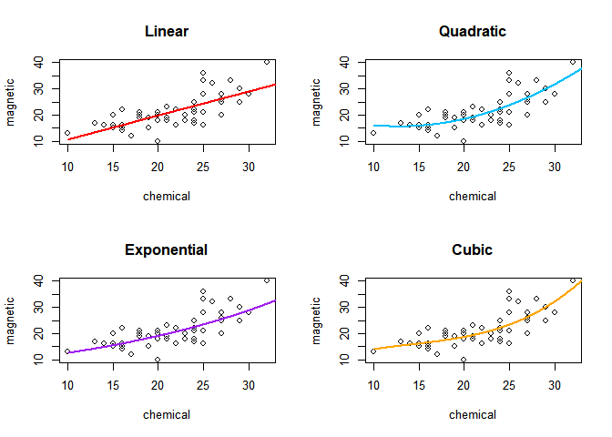

```r
## leave-one-out交叉验证
for (k in 1:n) {
  y = magnetic[-k]
  x = chemical[-k]

  # 线性模型
  L1 = lm(y ~ x)
  yhat1 = predict(L1, newdata = data.frame(x = chemical[k]))
  e1[k] = magnetic[k] - yhat1
  a_R21[k] = summary(L1)$adj.r.squared

  # 二次模型
  L2 = lm(y ~ x + I(x^2))
  yhat2 = predict(L2, newdata = data.frame(x = chemical[k]))
  e2[k] = magnetic[k] - yhat2
  a_R22[k] = summary(L2)$adj.r.squared

  # 指数模型
  L3 = lm(log(y) ~ x)
  logyhat3 = predict(L3, newdata = data.frame(x = chemical[k]))
  yhat3 = exp(logyhat3)
  e3[k] = magnetic[k] - yhat3
  a_R23[k] = summary(L3)$adj.r.squared

  # 三次模型
  L4 = lm(y ~ x + I(x^2) + I(x^3))
  yhat4 = predict(L4, newdata = data.frame(x = chemical[k]))
  e4[k] = magnetic[k] - yhat4
  a_R24[k] = summary(L4)$adj.r.squared
}

## 计算均方误差和调整后R方(均值)
mse = c(mean(e1^2), mean(e2^2), mean(e3^2), mean(e4^2))
adj_r_squared = c(mean(a_R21), mean(a_R22), mean(a_R23), mean(a_R24))

# 输出结果
results = data.frame(model_type = c("线性模型", "二次模型", "指数模型", "三次模型"),
                     mes = round(mse, 3),
                     adjR2 = round(adj_r_squared, 3))

knitr::kable(results, caption = "模型评估结果")
```

模型评估结果

| model_type | mes | adjR2 |
| --- | --- | --- |
| 线性模型 | 19.556 | 0.528 |
| 二次模型 | 17.852 | 0.577 |
| 指数模型 | 18.442 | 0.528 |
| 三次模型 | 18.178 | 0.574 |

### 结果分析：

$\hspace{1.5em}$根据输出结果，使用二次多项式回归的预测误差更小且调整后的$R^2$更大，这表明其既有较小的预测误差，又有较高的解释能力。模型残差诊断图像如下：

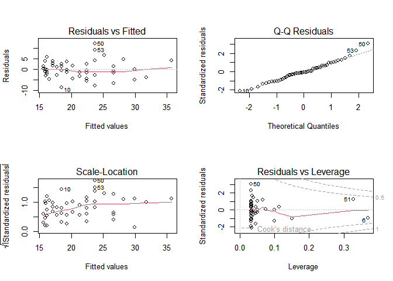

$\hspace{1.5em}$二次模型拟合看起来总体上是合理的，但存在一些潜在的问题。由Residuals vs Fitted（残差与拟合值图）可以看出，图中残差点随机分布在零线附近，但有一些点偏离较大，可能表明存在轻微的异方差性或有影响点；Q-Q Residuals中的点大体沿着对角线排列，但在尾部有一些偏离；Scale-Location（尺度-位置图）显示残差的绝对值随着拟合值的增加而增加，这表明可能存在异方差性；Residuals vs Leverage（残差与杠杆值图）中一些点的杠杆值较高。 鉴于此，需要进一步的模型诊断。

## *三、习题8.1*

$\hspace{1.5em}$实现Cramér-von Mises两样本检验的置换检验。Cramér-von Mises统计量用于比较两个样本的分布，通常表示为：

$$W_2 = \frac{mn}{(m+n)^2} \left( \sum_{i=1}^n (F_n(x_i) - G_m(x_i))^2 +
\sum_{j=1}^m (F_n(y_j) - G_m(y_j))^2 \right)$$

其中$F_n$是样本$x$的经验分布函数，$G_m$是样本$y$的经验分布函数。

### 代码实现：

```r
rm(list=ls())
# 加载数据
data(chickwts)
x=sort(as.vector(chickwts$weight[chickwts$feed == "soybean"]))
y=sort(as.vector(chickwts$weight[chickwts$feed == "linseed"]))
## 计算Cramér-von Mises统计量
cvm_statistic=function(x, y) {
  n=length(x); m=length(y)
  # 合并样本并计算经验分布
  pooled=c(x, y); Fn=ecdf(x)(pooled); Gm=ecdf(y)(pooled)
  # 计算 Cramér-von Mises 统计量
  W2=((n*m)/((n+m)^2))*(sum((Fn[1:n]-Gm[1:n])^2)+sum((Fn[(n+1):(n+m)]-Gm[(n+1):(n+m)])^2))
  return(W2)
}
t0=cvm_statistic(x, y) #原始统计量
## 置换检验
set.seed(23456)
R=999; z=c(x, y);n=length(x);K=1:length(z);reps=numeric(R)
for (i in 1:R) {
  k=sample(K, size=n, replace=FALSE)
  x1=z[k];  y1=z[-k]
  reps[i]=cvm_statistic(x1, y1)
}
## 计算p值
p=mean(abs(c(t0, reps)) >= abs(t0))
# 输出结果
cat(" Cramér-von Mises 统计量:", round(t0,3), "\n","p 值:", round(p,3), "\n")
```

```
##  Cramér-von Mises 统计量: 0.152
##  p 值: 0.385
```

### 结果分析：

$\hspace{1.5em}$Cramér-von Mises统计量不为零，但p值大于0.05，这意味着我们**没有足够的证据拒绝两个样本具有相同分布的原假设**。直方图展示了置换得到的 Cramér-von Mises 统计量的分布。红色线表示原始统计量的位置，可以看到，大多数置换得到的统计量都小于原始统计量，这与较高的 p 值一致。

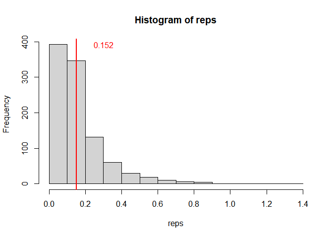

## *四、习题8.2*

$\hspace{1.5em}$对双变量斯皮尔曼秩相关检验进行置换检验，并将其与cor.test的p值进行比较。选取习题7.10中用过的ironslag数据集进行分析。

### 代码实现：

```r
rm(list=ls())
#加载数据
library(DAAG); data(ironslag)
magnetic=ironslag$magnetic; chemical=ironslag$chemical
# 计算Spearman相关系数和p值
spearman_test=cor.test(magnetic, chemical, method="spearman",exact = FALSE)
spearman_corr=spearman_test$estimate; p_value_cor=spearman_test$p.value
# 置换检验
set.seed(12345);R=999;comb=c(magnetic, chemical);n=length(magnetic)
reps=numeric(R);t0=spearman_corr
for (i in 1:R) {
    pp=sample(comb,replace = FALSE)
    x1=pp[1:n]; y1=pp[-(1:n)]
    reps[i]=cor(x1, y1, method="spearman")
}
# 计算置换检验p值
p_value_perm=mean(abs(c(t0, reps)) >= abs(t0))
# 输出结果
cat(" Spearman rank相关系数为:", round(spearman_corr,3),"\n",
    "cor.test的p值:",signif(p_value_cor,3),"\n",
    "置换检验的p值:", round(p_value_perm,3),"\n")
```

```
##  Spearman rank相关系数为: 0.743
##  cor.test的p值: 1.85e-10
##  置换检验的p值: 0.001
```

### 结果分析：

$\hspace{1.5em}$斯皮尔曼秩相关检验结果为0.743，表明磁性和化学特性之间存在强正相关关系,即随着磁性值的增加，化学值也倾向于增加。cor.test给出的p值（约为1.85e-10）非常小，表明这种相关性在统计上是显著的，几乎可以排除偶然因素的影响。置换检验的p值为0.001，同样支持这一结论，进一步验证了原始数据的相关性是可靠的。

# 作业2024-10-28

## *一、习题9.3*

$\hspace{1.5em}$使用Metropolis-Hastings算法从标准柯西分布中生成随机变量，丢弃链的前1000个样本，并比较生成的样本的分位数与标准柯西分布的分位数。进一步使用Gelman-Rubin方法评估链的收敛性。

$\hspace{1.5em}$标准柯西分布是一种具有无限方差的连续概率分布，其概率密度函数为
$$f(x) = \frac{1}{\pi \theta (1 + (x/\theta)^2)} ,$$
其中 $\theta = 1$ 和 $\eta = 0$为标准柯西分布的参数。

#### 算法思路：

1. **定义目标分布**：在本例中为标准柯西分布。
2. **定义提议分布**：使用正态分布作为提议分布，其简单且容易生成随机样本。
3. **实现Metropolis-Hastings算法**：
   - 初始化链的首个值。
   - 迭代生成提议值并计算接受概率。
   - 根据接受概率决定是否接受提议值。
4. **生成直方图和潜在尺度缩减因子图**：绘制直方图比较生成样本与理论分布的符合程度，并使用Gelman-Rubin评估链的收敛性。

### 代码实现与结果分析：

```r
rm(list=ls())
## 柯西分布
theta = 1; eta = 0
df = function(x) {
  1/(theta*pi*(1+((x-eta)/theta)^2))}
## 正态分布-Proposal distribution
dg = function(x, df) {
  dnorm(x = x, mean = df) }
# Proposal分布中生成随机变量
rg = function(df) {
  rnorm(n = 1, mean = df) }
## M-H
mh = function (N, df, dg, rg) {
  x = numeric(N); k = 0
  x[1] = rg(1) # 从Proposal中产生X1
  u = runif(N)
  for (i in 2:N) {
    xt = x[i-1]; y = rg(xt)
    r = df(y)*dg(xt, y)/(df(xt)*dg(y, xt)) # 计算接受概率
    if (u[i] <= r) {
      #均匀随机数<=接受概率时接受
      x[i] = y }
    else {
      # 否则拒绝候选值，保留当前值
      x[i] = xt ; k = k + 1 }
  }
  print(round(k/N,3)); return(x) # 返回生成的随机变量序列
}
## 执行M-H算法
set.seed(1234); n = 20000; k = 3 # 链数
X = matrix(nrow = k, ncol = n)
for (i in 1:k) {
  X[i, ] = mh(n, df, dg, rg)
}
```

```
## [1] 0.222
## [1] 0.232
## [1] 0.233
```

$\hspace{1.5em}$打印出的三条链的拒绝比例约为0.23，表明每条链中有23%的提议被拒绝，这表明提议分布与目标分布间有合理的平衡。

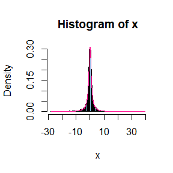

```r
#绘制直方图
x=X; hist(x, probability = TRUE, breaks = 100,col="skyblue")
plot.x = seq(min(x), max(x), 0.01);lines(plot.x, df(plot.x),col="deeppink")
```

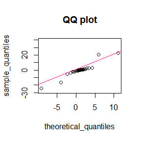

```r
# 绘制QQ图
sample_quantiles = t(apply(X, 1, quantile, probs = seq(0, 1, by = 0.1)))# 样本分位数
theoretical_quantiles = qcauchy(seq(0, 1, by = 1/n), 1, lower.tail = FALSE)#理论分位数
qqplot(theoretical_quantiles, sample_quantiles, main = "QQ plot")
abline(1, 2, col="deeppink")
```

$\hspace{1.5em}$从**直方图**可以看出，样本分布与理论柯西分布形状基本一致，尽管存在些许偏差，整体符合度较高。**QQ图**上大部分点都分布在红线附近，说明样本分位数与理论分位数非常接近，然而，尾部的一些点稍微偏离红线，可能暗示样本分布的尾部与理论分布相比有些许差异。表明样本与理论分布之间很好的一致性，Metropolis-Hastings采样器可能有效地从目标分布中生成了样本。

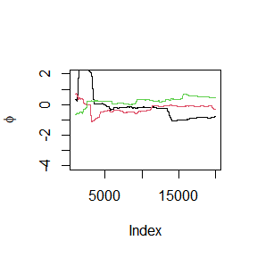

```r
## 计算潜在尺度缩减因子
Gelman.Rubin = function(phi) {
  phi = as.matrix(phi)
  k = nrow(phi); n = ncol(phi)
  phi.means = rowMeans(phi)
  B = n * var(phi.means)
  phi.w = apply(phi, 1, var)
  W = mean(phi.w)
  v.hat = W * (n - 1) / n + B / n
  r.hat = v.hat / W
  return(r.hat)
}
## 绘制累积均值(phi)图
b=1000; phi = t(apply(X, 1, cumsum))
for (i in 1:k) {
  phi[i,] = phi[i,] / (1:ncol(phi))
}
for (i in 1:k) {
  if (i == 1) {
    plot((b+1):n, phi[i,(b+1):n], ylim = c(-4, 2),
         type = "l", xlab = 'Index', ylab = bquote(phi))
  } else { lines((b+1):n, phi[i, (b+1):n], col = i) }
}
```

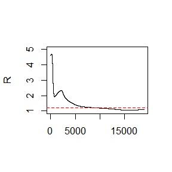

```r
## 绘制潜在尺度缩减因子图
rhat = rep(0, n)
for (j in (b+1):n) {
  rhat[j] = Gelman.Rubin(phi[, 1:j])
}
plot(rhat[(b+1):n], type = "l", xlab = "", ylab = "R",
     ylim = c(1, round(max(rhat[(b+1):n]),digits = 0)))
abline(h = 1.2, lty = 2,col='red')
```

## *二、习题9.8*

#### 算法思路：

1. 定义目标联合密度函数 $f(x, y)$。
2. 使用Gibbs抽样循环生成样本序列，循环中从条件分布中抽样更新样本值。
3. 绘制样本序列的散点图以可视化样本分布；计算样本序列的累积均值并绘制累积均值图。
4. 使用Gelman-Rubin方法检验样本序列的收敛性，Rhat值接近1.2通常表示样本序列收敛。

### 代码实现与结果分析：

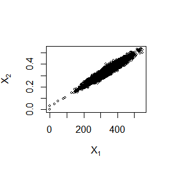

```r
rm(list=ls())
# 定义目标联合密度函数
n = 1000;a = 30;b = 60
df = function (x, y) {
  gamma(n+1)/(gamma(x+1)*gamma(n-x+1))*y^(x+a-1)*(1-y)^(n-x+b-1)}
m = 20000 ;burnin = 1000;set.seed(12345)
## Gibbs抽样循环
x = matrix(0, nrow = m, 2)
for (i in 2:m) {
  xt = x[i-1,]  # 获取当前迭代的样本值
  xt[1] = rbinom(1, n, xt[2])  # 从条件分布Binomial(n, y)中抽样
  xt[2] = rbeta(1, xt[1] + a, n - xt[1] + b)  # 从条件分布Beta(x + a, n - x + b)中抽样
  x[i,] = xt  # 更新样本值
}
plot(x[,1], x[,2], xlab = bquote(X[1]), ylab = bquote(X[2]),
     main = "", cex = 0.5, ylim = range(x[,2]))
```

$\hspace{1.5em}$散点图显示了二元随机样本序列的分布情况,图中点的分布围绕某个区域密集分布，这表明样本序列可能很好地从目标分布中抽样。

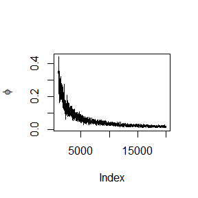

```r
## 绘制累积均值(phi)图
phi = t(t(apply(x, 1, cumsum)))
for (i in 1:nrow(phi)) {
  phi[i,] = phi[i,] / (1:ncol(phi))}
plot((burnin+1):m, phi[i, (burnin+1):m],
      type = "l", xlab = 'Index', ylab = bquote(phi))
```

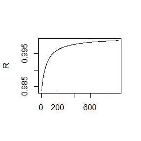

```r
# 计算潜在尺度缩减因子
Gelman.Rubin = function(phi) {
  phi = as.matrix(phi);  k = nrow(phi); n = ncol(phi)
  phi.means = rowMeans(phi); B = n * var(phi.means);
  phi.w = apply(phi, 1, var);  W = mean(phi.w)
  v.hat = W*(n-1)/n+B/n; r.hat = v.hat / W
  return(r.hat)
}
## 绘制潜在尺度缩减因子图
rhat = rep(0, n)
for (j in (b+1):n) {
  rhat[j] = Gelman.Rubin(phi[, 1:j])}
plot(rhat[(b+1):n], type = "l", xlab = "", ylab = "R")
abline(h = 1.2, lty = 2)
```

$\hspace{1.5em}$累积均值图显示累积均值在初期有较大的波动，然后随着迭代次数增加逐渐趋于稳定；潜在尺度缩减因子图中，Rhat值在初期迅速上升并趋于稳定，且一直保持在1.2以下，这表明链可能已经收敛。

## *三、证明题*

$\hspace{1.5em}$为证明给定MCMC的平稳性，需验证$K(s,r)f(s)=K(r,s)f(r)$,即如果从状态$s$开始，经过转移核$K$后，得到的分布和从状态$r$开始，经过转移核$K$后得到的分布相同，那么这个分布$f$就是平稳分布。

### 转移核的定义：

$$K(r, s) = 1(s \neq r) \alpha(r, s) g(s \mid r) + 1(s = r) \left[1 - \int
\alpha(r, s) g(s \mid r) ds\right]$$

详细平衡条件要求对于所有的 $s$和 $r$，$K(s, r) f(s) = K(r, s) f(r)$必须成立.

### 证明：

1. 当 $s \neq r$时：

$\hspace{1.5em}$此时，转移核的表达式为：
$$K(s, r) = \alpha(s, r) g(r \mid s)$$
$$K(r, s) = \alpha(r, s) g(s \mid r)$$
其中接受概率的定义为：
$$\alpha(s, r) = \min\left\{\frac{f(r) g(s \mid r)}{f(s) g(r \mid s)},
1\right\}$$
$$\alpha(r, s) = \min\left\{\frac{f(s) g(r \mid s)}{f(r) g(s \mid r)},
1\right\}$$

$\hspace{1.5em}$下证$\alpha(s, r) g(r \mid s) f(s) = \alpha(r, s) g(s \mid r) f(r)$.从左侧出发有：

$$\alpha(s, r) g(r \mid s) f(s) = \min\left\{1, \frac{f(r) g(s \mid
r)}{f(s) g(r \mid s)}\right\} g(r \mid s) f(s)$$
$$= \frac{f(r) g(s \mid r)}{f(s) g(r \mid s)} g(r \mid s) f(s) \quad
\text{(当 }\frac{f(r) g(s \mid r)}{f(s) g(r \mid s)} < 1\text{)}=
f(r) g(s \mid r)$$
当 $\frac{f(r) g(s \mid r)}{f(s) g(r \mid s)} \geq 1$ 时，左侧为$g(r \mid s) f(s)$

$\hspace{1.5em}$右侧：
$$\alpha(r, s) g(s \mid r) f(r) = \min\left\{1, \frac{f(s) g(r \mid
s)}{f(r) g(s \mid r)}\right\} g(s \mid r) f(r)$$
$$= \frac{f(s) g(r \mid s)}{f(r) g(s \mid r)} g(s \mid r) f(r) \quad
\text{(当 }\frac{f(s) g(r \mid s)}{f(r) g(s \mid r)} < 1\text{)} =
f(s) g(r \mid s)$$

当 $\frac{f(s) g(r \mid s)}{f(r) g(s \mid r)} \geq 1$ 时，右侧为：$g(s \mid r) f(r)$,左侧和右侧的相等关系成立。

$\hspace{1.5em}$代入详细平衡条件，得到：

$$\alpha(s, r) g(r \mid s) f(s) = \alpha(r, s) g(s \mid r) f(r)$$
故$K(s, r) f(s) = \alpha(s, r) g(r \mid s) f(s) = \alpha(r, s) g(s \mid r) f(r) = K(r, s) f(r)$成立。

2. **当 $s = r$ 时**：

   此时，转移核为：

   $$K(s, s) = 1 - \int \alpha(s, s) g(s \mid s) ds$$

   由于 $s = r$，我们可以写出：

   $$K(s, s) f(s) = \left[1 - \int \alpha(s, s) g(s \mid s) ds\right] f(s)$$
   $$K(r, r) f(r) = \left[1 - \int \alpha(r, r) g(r \mid r) dr\right] f(r)$$

   由于 $s = r$，所以 $K(s, s) = K(r, r)$ 且 $f(s) = f(r)$，这意味着：

$$K(s, s) f(s) = K(r, r) f(r)$$

即对于所有可能的 $s$ 和 $r$（无论是 $s \neq r$ 还是 $s = r$），都有 $K(s, r) f(s) = K(r, s) f(r)$。这证明了目标分布 $f$ 是给定 MCMC 算法的平稳分布。

## *一、习题11.3*

### 问题重述

$\hspace{1.5em}$要求完成以下任务：

1. 编写一个函数来计算给定数学表达式中的第$k$项，表达式为：

$$\sum_{k=0}^{\infty}\frac{(-1)^k}{k! 2^k}\frac{\|a\|^{2 k+2}}{(2 k+1)(2
k+2)}\frac{\Gamma\left(\frac{d+1}{2}\right)\Gamma\left(k+\frac{3}{2}\right)}{\Gamma\left(k+\frac{d}{2}+1\right)},$$

其中$d\geq1$是一个整数，$a$是$\mathbb{R}^d$中的一个向量$\|\cdot\|$表示欧几里得范数。要求进行适当的算术运算，以便可以计算出任意大的$k$和$d$的系数。

2. 修改函数，使其计算并返回总和。
3. 当$a = (1, 2)^T$时，计算。

### 问题分析

$\hspace{1.5em}$本题要求我们计算一个无穷级数的和，涉及到一些函数如伽玛函数、指数运算，当涉及到大数或小数时，在计算机上直接计算这些表达式可能会遇到数值稳定性问题。常采用**取对数**的方式解决，将乘法和除法转换为加法和减法，从而避免数值溢出或下溢。即：

$$e^{(-1)^k[(2k+2)\ln(\|a\|)+\ln(\Gamma(\frac{d+1}{2}))+\ln(\Gamma(k+\frac{3}{2}))-\ln(k!)-k\ln(2)
-\ln((2k+1)(2k+2))-\ln(\Gamma(k+\frac{d}{2}+1))]}$$

### 代码实现

```r
rm(list=ls())
## (a) 编写计算第k项的函数
calcu_kterm = function(a, k, d) {
  #对原式取对数--这里有一个log(k!)在0的位置需要定义一下
  if (k==0) log_factorial=0 else log_factorial=sum(log(1:k))
  log_term = 0+(2*k+2)*log(sum(a^2))+log(gamma((d+1)/2))+log(gamma(k+3/2))-
      log_factorial-k*log(2)-log((2*k+1)*(2*k+2))-log(gamma(k+d/2+1))
  term = ((-1)^k)*exp(log_term) # 还原
  return(term)
}
## (b) 计算并返回总和
# 最大计算次数为max_iter 当计算小于1e-10时停止计算
getSum = function(a,d,max_iter=1000,tol=1e-10){
  sum_value = 0; Final = calcu_kterm(a, 0, d)
  exp_sum_value = Final
  for (k in 1:max_iter) {
    current_term = calcu_kterm(a, k, d)
    sum_value = sum_value + current_term
    if (abs(current_term) < tol){
      break}
  }
  return(sum_value)
}
## (c) Evaluate the sum
a = c(1, 2) ; d = length(a)
result = getSum(a, d)
cat("计算结果约为:",result)
```

```
## 计算结果约为: -4.995031
```

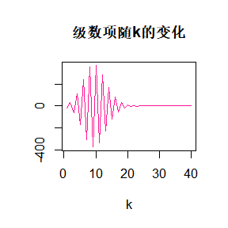

```r
absolute_values <- sapply(0:40, calcu_kterm, a = a, d = d)
plot(1:40, sapply(1:40, calcu_kterm, a = a, d = d), type = "l",
     main = "级数项随k的变化",xlab = "k",ylab="", col = "deeppink")
```

$\hspace{1.5em}$由图可以验证，随着k增大，级数不断收敛。

## *二、习题11.5*

### 问题重述

$\hspace{1.5em}$求解方程：

$$\frac{2\Gamma\left(\frac{k}{2}\right)}{\sqrt{\pi(k-1)}\Gamma\left(\frac{k-1}{2}\right)}\int_{0}^{c_{k-1}}\left(1+\frac{u^{2}}{k-1}\right)^{-k/2}
du = \frac{2\Gamma\left(\frac{k+1}{2}\right)}{\sqrt{\pi
k}\Gamma\left(\frac{k}{2}\right)}\int_{0}^{c_{k}}\left(1+\frac{u^{2}}{k}\right)^{-(k+1)/2}
du$$

其中，$c_k$定义为：

$$c_k = \sqrt{\frac{a^2 k}{k+1-a^2}}$$

### 问题分析

$\hspace{1.5em}$方程的左侧和右侧都是关于k的函数，包含积分和伽玛函数。

- 由于积分没有解析解，我们需要使用**数值积分**方法来近似计算积分的值，可以借助**integrate函数**使用自适应方法估计。
- 进一步地，需要找到一个a,使得方程两侧的值相等,转换为方程的**求根问题**，采用**Brent算法**求解。

### 代码实现

```r
rm(list=ls())
solve.equation = function(k) {
  # 定义方程的左右两边
  term = function(n, a) {
    integral = function(u) (1+u^2/(n-1))^(-n/2)
    ck = sqrt(a^2*n/(n+1-a^2))
    p = 2/sqrt(pi*(n-1))*exp(lgamma(n/2)-lgamma((n-1)/2))
    return(p*integrate(integral, 0, ck)$value)  # 计算积分并返回
  }
  f = function(a){
    term(k, a)-term(k+1, a)}
  if (f(1.5)*f(2) < 0) {
    r = uniroot(f, c(0.5, 2))$root  # 求解方程
  } else r = NA #出现NA则通过绘制k对应图像调整区间
  return(r)
}
# 不同的k值求解
options(digits=4)
rs = sapply(c(4:25,100,500,1000), solve.equation)
print(rs)
```

```
##  [1] 1.811 1.827 1.830 1.829 1.825 1.821 1.816 1.811 1.807 1.803 1.799 1.796
## [13] 1.793 1.790 1.787 1.785 1.783 1.781 1.779 1.777 1.775 1.774 1.743 1.734
## [25] 1.733
```

## *三*

### 问题重述

$\hspace{1.5em}$假设 $T_1,\ldots,T_n$是从期望为$\lambda$的指数分布中独立同分抽取的样本。由于右删失，大于$\tau$的值不会被观察到，因此观察到的值是$Y_i=T_iI(T_i\leq\tau)+\tau I(T_i>\tau)$,$i=1,\ldots,n$。假设 $\tau=1$，并且观察到的$Y_i$值如下：

$0.54, 0.48, 0.33, 0.43, 1.00, 1.00, 0.91, 1.00, 0.21, 0.85$

使用E-M估计 $\lambda$，并与观察数据的最大似然估计（MLE）结果进行比较。

### 问题分析

##### 步骤 1: 定义混合分布

混合分布由两部分组成：

1. $T_i \leq \tau$ 时，$Y_i = T_i$，其概率密度函数为 $\lambda e^{-\lambda T_i}$。
2. $T_i > \tau$ 时，$Y_i = \tau$。

##### 步骤 2: E-M 算法

- E-step：计算每个观测值$Y_i$来自指数分布的部分的期望值，即$Z_i = P(T_i \leq \tau | Y_i, \lambda)$。
- M-step：更新$\lambda$的估计值，使得对数似然函数最大化。

### 代码实现

$\hspace{1.5em}$根据公式 $E[X | X > \theta] = \frac{1}{\lambda} + \theta$，根据当前的$\lambda$和$\theta$计算调整后的条件期望值。

```r
rm(list=ls())
Y=c(0.54, 0.48, 0.33, 0.43, 1.00, 1.00, 0.91, 1.00, 0.21, 0.85)
tau=1.0  # 删失阈值
# EM算法
EM=function(Y, tau, max_iter=100,tol=1e-6) {
  n=length(Y); lamb=1
  for (j in 1:max_iter) {
    expect=ifelse(Y<tau, Y, tau+1/lamb)  # E步
    new_lamb=1 / mean(expect)  # M步
    if (abs(new_lamb-lamb)<tol) {# 收敛判定
      break}
    lamb=new_lamb
  }
  return(lamb)
}
# 调用EM算法
lambda_EM=EM(Y, tau)
cat("EM算法估计的lambda：", lambda_EM, "\n")
```

```
## EM算法估计的lambda： 1.037
```

$\hspace{1.5em}$最大似然估计（MLE）可以通过直接最大化似然函数来实现。对于截断数据，似然函数可以写为：
$$L(\lambda) = \prod_{i=1}^n \left( \lambda e^{-\lambda Y_i} \right)^{Z_i}
\left( e^{-\lambda \tau} \right)^{1-Z_i}$$

```r
# 负对数似然函数
neg_log_likelihood <- function(lambda, Y, tau) {
  # 对应删失和非删失数据的似然项
  term1 <- sum(log(lambda) - lambda * Y[Y < tau])  # 未删失数据
  term2 <- sum(log(1 - exp(-lambda * tau)) * (Y >= tau))  # 删失数据
  return(-(term1 + term2))
}
# MLE估计
MLE_lambda <- function(Y, tau) {
  # 最小化负对数似然
  result <- optimize(neg_log_likelihood, interval = c(0.0001, 10), Y = Y, tau = tau)
  return(result$minimum)
}
# 运行MLE估计
lambda_MLE <- MLE_lambda(Y, tau)
cat("最大似然估计的lambda：", lambda_MLE, "\n")
```

```
## 最大似然估计的lambda： 2.101
```

# 作业2024-11-11

## *一、习题11.7*

$\hspace{1.5em}$最小化目标函数 $4x+2y+9z$，受以下约束条件限制：

1. $2x+y+z \leq 2$
2. $x-y+3z \leq 3$
3. $x \geq 0$, $y \geq 0$, $z \geq 0$

#### 代码实现

$\hspace{1.5em}$线性规划问题可以使用`lpSolve`包解决。

```r
rm(list=ls())
library(lpSolve)
# 目标函数系数(min 4x+2y+9z)
objective=c(4, 2, 9)
# 约束条件
constr=rbind(
  c(2, 1, 1), #  2x+y+z <= 2
  c(1, -1, 3) #  x-y+3z <= 3
)
direction=c("<=", "<=")
rhs=c(2, 3)
# 定义变量的下界(x, y, z >= 0)
lower.bounds=c(0, 0, 0)
# 使用lp函数求解线性规划问题
result=lp("min", objective, constr, direction, rhs,all.int=FALSE)
# 输出结果
result$solution
```

```
## [1] 0 0 0
```

#### 结果验证

$\hspace{1.5em}$输出结果为[0, 0, 0]，这个解是一个正确的最优解，它符合所有约束条件并最小化了目标函数。

$\hspace{1.5em}$从目标函数$4x+2y+9z$来看，所有的系数都是正数(4、2、9)。因此，最优解会倾向于将 $x$、$y$ 和 $z$ 的值尽可能小，以便最小化目标函数。

1. 对第一个约束 $2*0+0+0=0 \leq 2$ 是满足的。
2. 对第二个约束 $0-0+3*0=0 \leq 3$ 也是满足的。

这表明 $x=0$, $y=0$, $z=0$ 是一个可行解，并且目标函数的值为：

$$4*0+2*0+9*0=0$$

由于目标函数值为零，并且没有负值的系数，因此这就是最小值。

## *二、Exercises 3, 4, 5*

### *Exercises 3*

$\hspace{1.5em}$分别使用循环和lapply()函数，根据存储在这个列表中的公式来拟合mtcars数据集的线性模型：

```r
formulas=list(
  mpg ~ disp,
  mpg ~ I(1/disp),
  mpg ~ disp+wt,
  mpg ~ I(1/disp)+wt)
```

#### 代码实现

```r
# 加载数据集和所需包(microbenchmark测量两者的执行时间)
data(mtcars);library(microbenchmark)
## 一、使用 for 循环
time_for1=microbenchmark(
  for_loop={mod_for1=list()
    for(i in 1:length(formulas)) {
      mod_for1[[i]]=lm(formulas[[i]], data=mtcars)
    }},  times=10)
# 打印模型2结果
print(summary(mod_for1[[2]]))
```

```
##
## Call:
## lm(formula = formulas[[i]], data = mtcars)
##
## Residuals:
##    Min     1Q Median     3Q    Max
## -3.738 -1.822 -0.075  1.049  4.610
##
## Coefficients:
##             Estimate Std. Error t value Pr(>|t|)
## (Intercept)   10.752      0.799    13.4  3.1e-14 ***
## I(1/disp)   1557.674    114.894    13.6  2.5e-14 ***
## ---
## Signif. codes:  0 '***' 0.001 '**' 0.01 '*' 0.05 '.' 0.1 ' ' 1
##
## Residual standard error: 2.29 on 30 degrees of freedom
## Multiple R-squared:  0.86,   Adjusted R-squared:  0.855
## F-statistic:  184 on 1 and 30 DF,  p-value: 2.49e-14
```

```r
## 二、使用 lapply()
time_lapply1=microbenchmark(
  lapply_loop={
    mod_lapply1=lapply(formulas, function(f) lm(f, data=mtcars))
  },times=10 )
# 打印模型2结果
print(summary(mod_lapply1[[2]]))
```

```
##
## Call:
## lm(formula = f, data = mtcars)
##
## Residuals:
##    Min     1Q Median     3Q    Max
## -3.738 -1.822 -0.075  1.049  4.610
##
## Coefficients:
##             Estimate Std. Error t value Pr(>|t|)
## (Intercept)   10.752      0.799    13.4  3.1e-14 ***
## I(1/disp)   1557.674    114.894    13.6  2.5e-14 ***
## ---
## Signif. codes:  0 '***' 0.001 '**' 0.01 '*' 0.05 '.' 0.1 ' ' 1
##
## Residual standard error: 2.29 on 30 degrees of freedom
## Multiple R-squared:  0.86,   Adjusted R-squared:  0.855
## F-statistic:  184 on 1 and 30 DF,  p-value: 2.49e-14
```

```r
## 对比二者运行效率
print(time_for1)
```

```
## Unit: milliseconds
##      expr   min    lq mean median    uq   max neval
##  for_loop 5.048 5.104 5.25  5.133 5.306 6.077    10
```

```r
print(time_lapply1)
```

```
## Unit: milliseconds
##         expr   min    lq mean median    uq   max neval
##  lapply_loop 2.471 2.486  2.7   2.54 2.611 4.146    10
```

#### 结果解释

$\hspace{1.5em}$输出说明：

- min：最小执行时间；lq：第一四分位数；mean：平均执行时间；median：中位数执行时间
- uq：第三四分位数；max：最大执行时间；neval：测试执行次数(10 次)

$\hspace{1.5em}$通过打印结果可以看到，**两种方法在四种模型下的拟合结果都相同**。

$\hspace{1.5em}$从**运行效率**来看，lapply()比for循环更高效。这是因为它是向量化的，并且 R 的内部优化通常能使 lapply() 执行得更快。

### *Exercises 4*

$\hspace{1.5em}$在不使用匿名函数的情况下，使用for循环和lapply()函数，对下面每个mtcarsbootstrap样本上拟合模型mpg~disp。

```r
bootstraps=lapply(1:10, function(i) {
  rows=sample(1:nrow(mtcars), replace=TRUE)
  mtcars[rows, ]})
```

#### 代码实现

```r
library(microbenchmark)
## 一、使用 for 循环
time_for2=microbenchmark(
  for_loop={
    mod_for2=list()
    for(i in 1:length(bootstraps)) {
      mod_for2[[i]]=lm(mpg ~ disp, data=bootstraps[[i]])}
    },times=10)
## 二、使用 lapply()
fit_model=function(bootstrap_data) {# 定义拟合模型的函数
  lm(mpg ~ disp, data=bootstrap_data)}
time_lapply2=microbenchmark(
  lapply_loop={mod_lapply2=lapply(bootstraps, fit_model)},times=10)
## 比较两个方法的第一个模型结果
identical(coef(mod_for2[[1]]),coef(mod_lapply2[[1]]))#输出为True即相同
```

```
## [1] TRUE
```

```r
## 打印比较效率
print(time_for2);print(time_lapply2)
```

```
## Unit: milliseconds
##      expr   min    lq  mean median   uq   max neval
##  for_loop 7.741 7.835 8.302  8.017 8.99 9.009    10
```

```
## Unit: milliseconds
##         expr   min    lq  mean median    uq   max neval
##  lapply_loop 4.928 4.948 5.296  5.014 5.225 7.302    10
```

#### 结果解释

$\hspace{1.5em}$输出说明，两种方法得到的结果相同，且lapply()明显快于for循环。

### *Exercises 3*

$\hspace{1.5em}$对于前两个练习中的每个模型，使用下面的函数提取R²值：

```r
rsq=function(mod) summary(mod)$r.squared
```

#### 代码实现

```r
options(digits=3)
## 练习1
R1_1=lapply(mod_for1,rsq);R1_2=lapply(mod_lapply1,rsq) #提取R²值
df1=data.frame(mod_for=unlist(R1_1),mod_lapply=unlist(R1_2))
knitr::kable(t(df1),caption="练习一中四个模型的结果")
```

练习一中四个模型的结果

| mod_for | 0.718 | 0.86 | 0.781 | 0.884 |
| --- | --- | --- | --- | --- |
| mod_lapply | 0.718 | 0.86 | 0.781 | 0.884 |

```r
## 练习2
R2_1=lapply(mod_for2,rsq);R2_2=lapply(mod_lapply2,rsq) #提取R²值
df2=data.frame(mod_for=unlist(R2_1),mod_lapply=unlist(R2_2))
knitr::kable(t(df2),caption="练习二中模型结果")
```

练习二中模型结果

| mod_for | 0.633 | 0.617 | 0.799 | 0.779 | 0.768 | 0.723 | 0.77 | 0.725 | 0.689 | 0.662 |
| --- | --- | --- | --- | --- | --- | --- | --- | --- | --- | --- |
| mod_lapply | 0.633 | 0.617 | 0.799 | 0.779 | 0.768 | 0.723 | 0.77 | 0.725 | 0.689 | 0.662 |

## *三、Excecises 3 and 6*

### *Exercises 3*

$\hspace{1.5em}$以下代码模拟了对非正态数据进行t检验的性能。使用sapply()和一个匿名函数从每次试验中提取p值。

```r
trials=replicate(
  100,
  t.test(rpois(10, 10), rpois(7, 10)),
  simplify=FALSE)
```

- 额外挑战：通过直接使用[[来去掉匿名函数。

#### 代码实现

```r
## 使用 sapply() 和匿名函数提取每次试验中的 p 值
p_values1=sapply(trials, function(x) x$p.value)
```

$\hspace{1.5em}$sapply()将匿名函数应用于trials列表的每个元素，提取每个t.test结果中的p.value，并返回一个包含所有 p 值的向量。

```r
## 额外挑战：使用 sapply() 和 [[ 来提取 p.value
p_values2=sapply(trials, `[[`, "p.value")
```

$\hspace{1.5em}$`[[` 是一种通过名称访问列表中元素的方式，允许通过名称或索引提取元素。与使用 $ 的方式是等效的， [[ 灵活性更高。

### *Exercises 6*

$\hspace{1.5em}$实现一个结合Map()和vapply()的函数，创建一个lapply()的变体，该变体并行地遍历所有输入，并将输出存储在向量(或矩阵)中。

#### 代码实现

```r
m_v_lapply=function(..., FUN) {
  args=list(...)  # 获取输入的列表或向量
  result=Map(FUN, args[[1]], args[[2]]) # 将所有输入的参数传入FUN
  if (length(result) > 0) { # 获取第一个元素的类型来推断 FUN.VALUE 类型
    first_value=result[[1]]
    if (is.numeric(first_value)) {
      result=vapply(result, function(x) x, FUN.VALUE=numeric(1))
    } else if (is.character(first_value)) {
      result=vapply(result, function(x) x, FUN.VALUE=character(1))
    } else if (is.logical(first_value)) {
      result=vapply(result, function(x) x, FUN.VALUE=logical(1))
    } else if (is.list(first_value)) {
      result=vapply(result, function(x) x, FUN.VALUE=list())
    } else {stop("返回类型不可识别")}
  }
  return(result)}
## 运行示例1：加法
# 定义一个简单的函数：两个输入的乘法
multi_fun=function(x, y) {
  return(x*y)}
input1=1:5; input2=6:10
output1=m_v_lapply(input1, input2, FUN=multi_fun)
print(output1)
```

```
## [1]  6 14 24 36 50
```

- `...` 用来接收输入参数的列表，可以是多个向量或其他类型的输入。
- `FUN` 用来指定希望对每一对输入参数执行的操作。

## *三、Excecise4 4-5*

### *Exercises 4*

$\hspace{1.5em}$制作一个更快版本的chisq.test()函数，该函数仅在输入为两个无缺失值的数值向量时计算卡方检验统计量。

$\hspace{1.5em}$卡方检验(Pearson’s Chi-squared test)用于检验两个分类变量是否独立。公式如下：

$$\chi^2=\sum \frac{(O_i-E_i)^2}{E_i}$$

其中： - $O_i$ 是观察频数(Observed Frequency) - $E_i$ 是期望频数(Expected Frequency)，计算公式为：

$$E_i=\frac{(行的总和) \times (列的总和)}{总样本数}$$

```r
chisq_test=function(x, y) {
  if (!is.numeric(x) || !is.numeric(y)) {# 输入是否为数值向量
    stop("两个输入都必须是数值向量")}
  if (length(x) != length(y)) {# 向量长度是否相等
    stop("两个向量的长度必须相同") }
   if (any(is.na(x)) || any(is.na(y))) {# 是否有缺失值
    stop("向量中不允许有缺失值")}
    c_table=table(x, y) # 创建列联表
    # 计算期望频数矩阵
    row_sum=rowSums(c_table);col_sum=colSums(c_table);total_sum=sum(c_table)
    expected=outer(row_sum, col_sum, "*")/total_sum
    # 卡方统计量
    chi_squared_stat=sum((c_table-expected)^2/expected)
    # 自由度、p值
    df=(nrow(c_table)-1)*(ncol(c_table)-1)
    p_value=1-pchisq(chi_squared_stat, df)
    # 返回结果
    return(list(chi_squared_stat=chi_squared_stat,df=df,p_value=p_value))
}
## 示例使用
x=c(10,15,20,25,30); y=c(15,10,25,20,50)
result1=chisq_test(x, y)
print(result1)
```

```
## $chi_squared_stat
## [1] 20
##
## $df
## [1] 16
##
## $p_value
## [1] 0.22
```

### *Exercises 5*

$\hspace{1.5em}$对于两个无缺失值的整数向量输入的情况，制作一个更快版本的 table() 函数，并用它来加速上面的卡方检验。

#### 代码实现

```r
fast_table=function(x, y) {
  x_levels=as.integer(factor(x))
  y_levels=as.integer(factor(y))
  # 初始化空的频数表
  counts=matrix(0, nrow=length(unique(x)), ncol=length(unique(y)))
  # 填充频数表
  for (i in seq_along(x)) {
    counts[x_levels[i], y_levels[i]]=counts[x_levels[i], y_levels[i]]+1
  }
  return(counts)}
# 使用之前定义的 chisq_test 函数,修改列联表定义的部分，进行卡方检验
chisq_test_fast=function(x, y) {
     c_table=fast_table(x, y) # 创建列联表
    # 计算期望频数矩阵
    row_sum=rowSums(c_table);col_sum=colSums(c_table);total_sum=sum(c_table)
    expected=outer(row_sum, col_sum, "*")/total_sum
    # 卡方统计量
    chi_squared_stat=sum((c_table-expected)^2/expected)
    # 自由度、p值
    df=(nrow(c_table)-1)*(ncol(c_table)-1)
    p_value=1-pchisq(chi_squared_stat, df)
    # 返回结果
    return(list(chi_squared_stat=chi_squared_stat,df=df,p_value=p_value))
}
## 示例使用
x=c(10,15,20,25,30); y=c(15,10,25,20,50)
result2=chisq_test_fast(x, y)
print(result2)
```

```
## $chi_squared_stat
## [1] 20
##
## $df
## [1] 16
##
## $p_value
## [1] 0.22
```

```r
## 对比运行效率
library(microbenchmark)
time1=microbenchmark(chisq_test(x, y),times=50);print(time1)
```

```
## Unit: microseconds
##              expr min  lq mean median  uq max neval
##  chisq_test(x, y) 242 245  251    247 248 396    50
```

```r
time2=microbenchmark(chisq_test_fast(x, y),times=50);print(time2)
```

```
## Unit: microseconds
##                   expr min  lq mean median  uq max neval
##  chisq_test_fast(x, y) 150 151  157    154 156 291    50
```

$\hspace{1.5em}$可以看到，使用改进的`fast_table()`后，输出结果不变，而运行速度得到明显地提升。

# 作业2024-11-18

### 作业要求

$\hspace{1.5em}$根据Exercise_9.8写一个Rcpp函数，使用“**qqplot**”函数比较编写的Rcpp函数生成的随机数与R中相应函数生成的随机数。使用“**microbenchmark**”函数比较这两个函数的计算时间。

### 代码实现

#### 1. C++ function

$\hspace{1.5em}$首先创建一个m行2列的矩阵存储样本，对其赋初始值后进行Gibbs抽样循环：从条件分布Binomial(n, y)抽样更新 x1，从条件分布Beta(x + a, n - x + b)抽样更新x2。

- 输入参数：样本数 m、burnin 样本数、n、a、b。
- 使用 R::rbinom 和 R::rbeta 来从二项式和 Beta 分布中抽样。

$\hspace{1.5em}$C++函数 **gibbs_sampler.cpp**具体定义如下：

```r
#include <Rcpp.h>
using namespace Rcpp;

// [[Rcpp::export]]
NumericMatrix gibbs_sampling(int m, int n, double a, double b) {
  NumericMatrix x(m, 2);
  double xt_1=0.5;
  double xt_2=0.5;
  for (int i=1; i < m; ++i) {
    xt_1=R::rbinom(n, xt_2);
    xt_2=R::rbeta(xt_1 + a, n - xt_1 + b);
    x(i, 0)=xt_1;
    x(i, 1)=xt_2;
  }
  return x;
}
```

#### 2. Rcpp v.s. R

$\hspace{1.5em}$首先导入定义的Rcpp函数和需要的包：Rcpp、microbenchmark。

```r
rm(list=ls())
library(Rcpp);library(microbenchmark)
## 载入Rcpp函数
sourceCpp('../vignettes/gibbs.cpp')
```

$\hspace{1.5em}$使用“**qqplot**”函数比较编写的Rcpp函数生成的随机数与R中相应函数生成的随机数。使用“**microbenchmark**”函数比较这计算时间。

```r
# 设置参数和种子--Beta分布的参数与Gibbs抽样过程的迭代次数m
n=1000;a=30;b=60;m=10000
set.seed(1234)
## R编写Gibbs抽样函数
R_gibbs_sampling=function(m, n, a, b) {
  x=matrix(0, nrow=m, ncol=2)
  for (i in 2:m) {
    xt=x[i-1,]  # 当前迭代的样本值
    xt[1]=rbinom(1, n, xt[2])   # Binomial(n,y)中抽样
    xt[2]=rbeta(1,xt[1]+a,n-xt[1]+b) # Beta(x+a,n-x+b)中抽样
    x[i,]=xt # 更新样本值
  }
  return(x)
}

## 使用Rcpp的Gibbs抽样
x_rcpp=gibbs_sampling(m, n, a, b)
## 使用R编写的Gibbs抽样
x_r=R_gibbs_sampling(m, n, a, b)
```

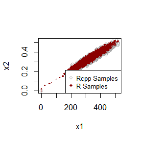

```r
## 在一张图上plot散点图
par(mfrow=c(1, 1))
plot(x_rcpp[,1], x_rcpp[,2], xlab = 'x1', ylab ='x2',main = "",
     cex = 1, ylim = range(x_rcpp[,2]),col = 'darkgray',pch = 1)
par(new=TRUE)
plot(x_r[,1], x_r[,2],cex = 0.5,xlab = '', ylab ='',main = "",
     xaxt = 'n',yaxt = 'n',col ='darkred',pch = 18)
legend("bottomright", legend = c("Rcpp Samples", "R Samples"),
       col = c("darkgray", "darkred"), pch = c(1, 18), cex = 0.8)
```

- 通过 **plot()**可以观察到Gibbs抽样生成的二元样本序列的分布情况。可以看到二者围绕某个区域密集分布，样本序列可能很好地从目标分布中抽样；同时二者分布形态相似。

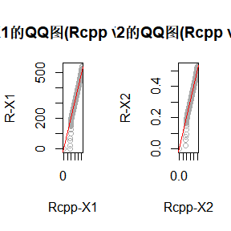

```r
## QQ图比较
par(mfrow=c(1, 2))
qqplot(x_rcpp[,1], x_r[,1], main="X1的QQ图(Rcpp v.s. R)",
       xlab="Rcpp-X1", ylab="R-X1",col = "darkgray")
abline(0, 1, col = "red")  # 添加y=x参考线
qqplot(x_rcpp[,2], x_r[,2], main="X2的QQ图(Rcpp v.s. R)",
       xlab="Rcpp-X2", ylab="R-X2",col = "darkgray")
abline(0, 1, col = "red")  # 添加y=x参考线
```

- 通过**qqplot()**可以检验生成的样本是否符合预期，如果两者生成的随机数分布一致，点会接近于一条直线。从图可以看出，大部分点都紧密地围绕在对角线附近，仅在尾部区域可能存在一些偏差。这表明**Rcpp和R生成的样本序列的分布非常相似**。

```r
## 两种方法的计算时间-重复10次结果
ts=microbenchmark(
  Rcpp=gibbs_sampling(m,n,a,b),
  R=R_gibbs_sampling(m,n,a,b),
  times=10)
knitr::kable(summary(ts))
```

| expr | min | lq | mean | median | uq | max | neval |
| --- | --- | --- | --- | --- | --- | --- | --- |
| Rcpp | 2.88 | 2.89 | 3.03 | 2.91 | 2.94 | 4.09 | 10 |
| R | 30.85 | 31.19 | 32.71 | 32.72 | 33.36 | 35.10 | 10 |

- 通过 **microbenchmark()**可以比较二者实现性能，明显看到，通过C++代码实现的Rcpp***速度快了10倍左右**，通过编写Rcpp函数**大幅度提升了代码运行效率**。

#### 3. 回到Exercise9.8上–收敛性验证

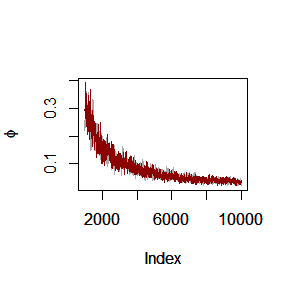

```r
## 累积均值(phi)图
phi=function(x,c="darkred",y='n'){
  burnin=1000 # 不稳定的烧入期
  phi = t(t(apply(x, 1, cumsum)))
  for (i in 1:nrow(phi)) {
    phi[i,] = phi[i,] / (1:ncol(phi))}
  plot((burnin+1):m, phi[i, (burnin+1):m],
       type = "l", xlab = 'Index', ylab = bquote(phi),
       col=c,yaxt = y)
}
phi(x_r,c="darkgray",y='s');par(new=TRUE);phi(x_rcpp)
```

- **累积均值图**：绘制累积均值图，用于观察样本序列是否趋于稳定。可以看到，**两种方法累积均值图显示样本序列都是趋于稳定的**，符合收敛性要求。

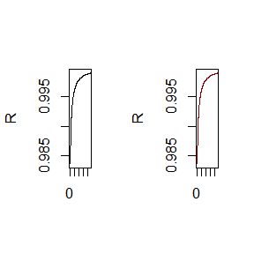

```r
## 绘制潜在尺度缩减因子图
rhat=function(x,c='darkred'){
  ## 计算潜在尺度缩减因子
  phi = t(t(apply(x, 1, cumsum)))
  Gelman.Rubin = function(phi) {
    phi = as.matrix(phi);  k = nrow(phi); n = ncol(phi)
    phi.means = rowMeans(phi); B = n * var(phi.means);
    phi.w = apply(phi, 1, var);  W = mean(phi.w)
    v.hat = W*(n-1)/n+B/n; r.hat = v.hat / W
    return(r.hat)
}
  rhat = rep(0, n)
  for (j in (b+1):n) {
    rhat[j] = Gelman.Rubin(phi[, 1:j])
    }
  plot(rhat[(b+1):n], type = "l", xlab = "", ylab = "R",col=c)
  abline(h = 1.2, lty = 2,col='red') # 小于1.2认为是收敛
}
par(mfrow=c(1, 2))
rhat(x_r,c="black");rhat(x_rcpp)
```

- **Gelman-Rubin 检验**：绘制Rhat值图，观察是否低于1.2，小于1.2认为样本序列已经收敛。**图中两种方法的Rhat值始终低于1.2，充分表明序列已经收敛**。